# Analyse de données - Rapport

Killian Blain

2022-12-14

## Analyse en composantes principales

# 1.

```r
d <- read.table("Eaux.data", header = TRUE)
d
```

```
##                Nom     Pays Bicarbonates Sulfates Chlorures Calcium Magnesium
## 1    Aix-les-Bains     F-73          341       27         3      84        23
## 2            Arvie     F-63         2195       31       387     170        92
## 3           Badoit     F-42         1300       40        40     190        85
## 4        Beckerish     F-68          263       23         9      91         5
## 5         Cayranne     F-84          287        3         5      44        24
## 6          Chambon     F-45          298        9        23      96         6
## 7          Contrex     F-88          403     1187         9     486        84
## 8      Cristal-Roc     F-72          200       15         8      70         2
## 9        Saint-Cyr     F-45          250        5        20      71         6
## 10           Evian     F-74          357       10         4      78        24
## 11          Ferita   Italie          311       14        18      73        18
## 12           Hepar     F-88          403     1479        10     555       110
## 13 Saint-Hyppolite     F-37          256        6        23      86         3
## 14         Laurier     F-77          186       10        16      64         4
```

[output cut: 49 more lines]

# 2.

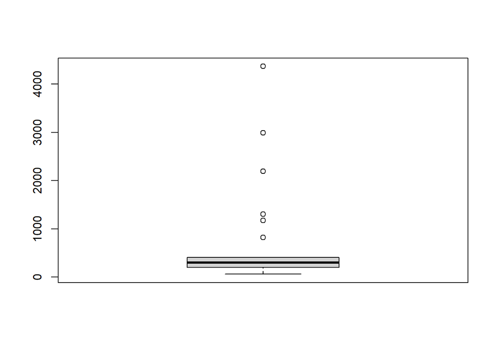

```r
boxplot(d$Bicarbonates)
```

On remarque une concentration autour d’environ 300 mais il y a également quelques valeurs extrêmes allant jusqu’à plus de 4000.

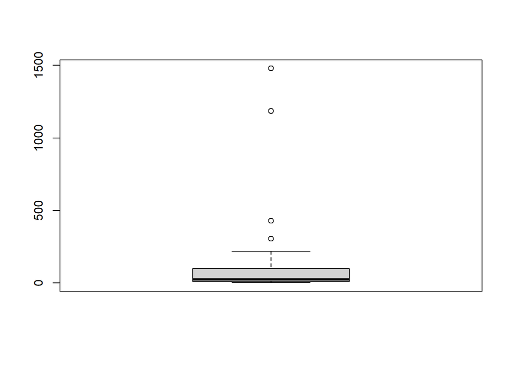

```r
boxplot(d$Sulfates)
```

On observe encore une fois une concentration de valeurs autour de 50 avec quelques valeurs extrêmes.

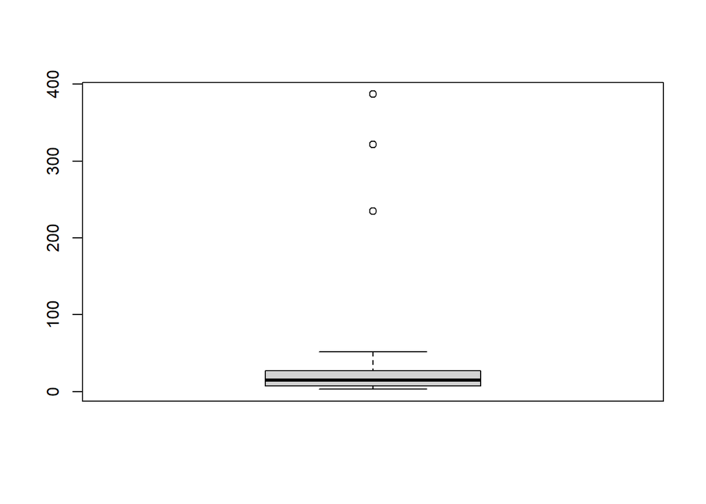

```r
boxplot(d$Chlorures)
```

Cette fois-ci, on a moins de variables extrêmes et des valeurs groupées autour de 25.

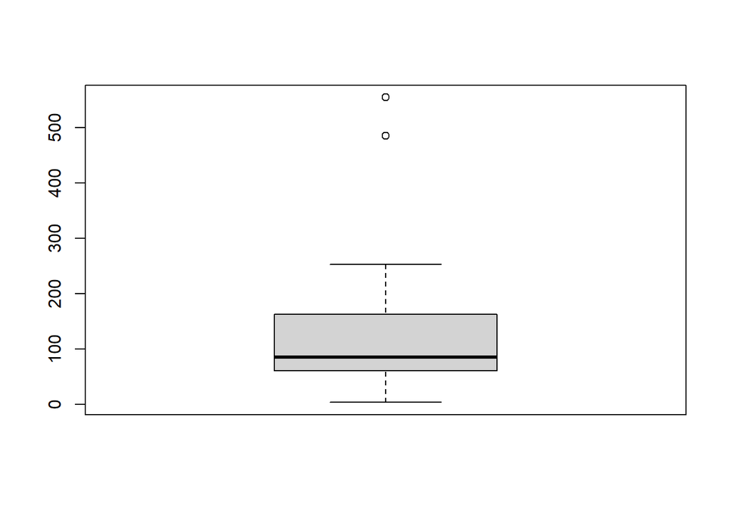

```r
boxplot(d$Calcium)
```

On a ici des valeurs autour de 100 et presque aucune valeur extrême.

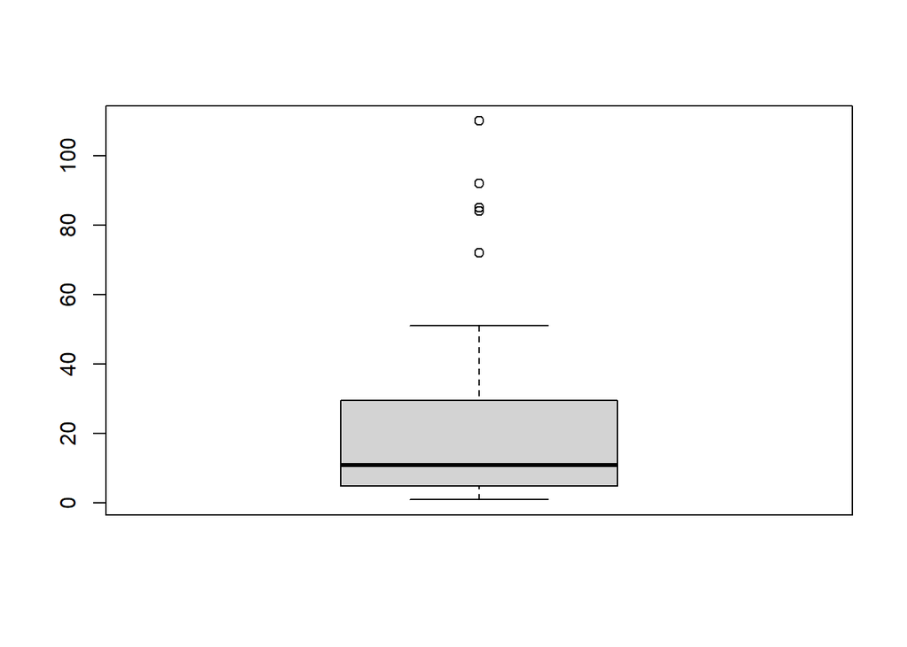

```r
boxplot(d$Magnesium)
```

On a des valeurs centrées autour de 20 et quelques valeurs extrêmes.

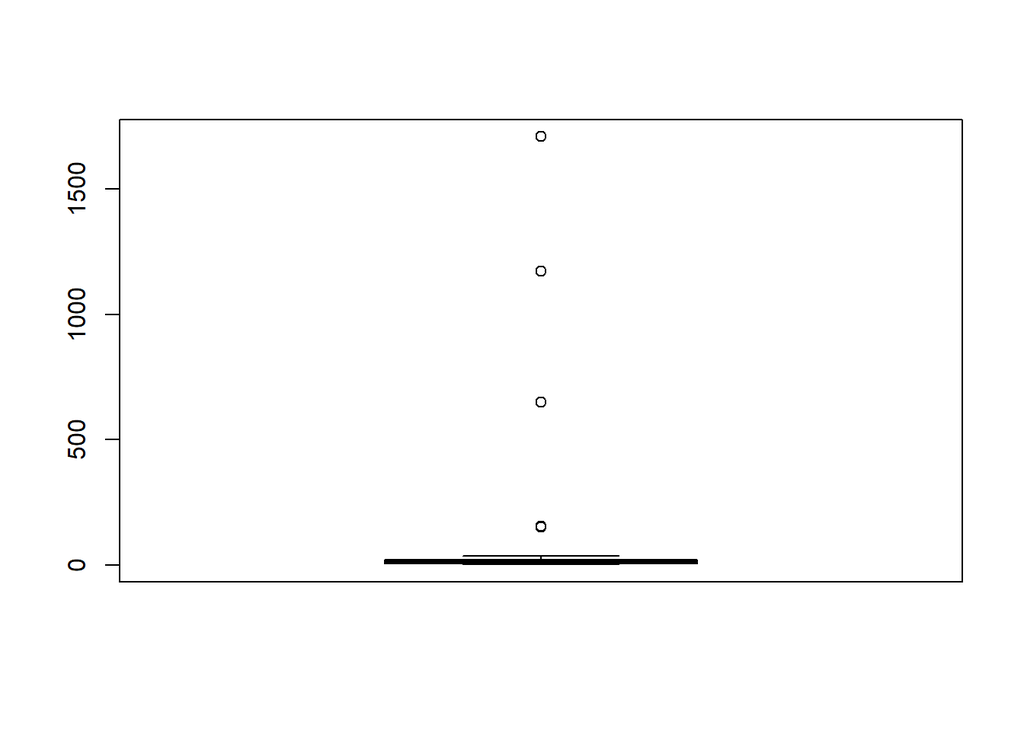

```r
boxplot(d$Sodium)
```

Le graphe est dur à lire, on a l’air d’avoir majoritairement des petites valeurs (en dessous de 50) mais plusieurs valeurs très extrêmes sont présentes (plus de 1000).

# 3.

```r
cov(d[,-c(1,2)])
```

```
##              Bicarbonates   Sulfates   Chlorures     Calcium Magnesium
## Bicarbonates   881787.632   4057.470 75563.23441  9564.32473 5539.8591
## Sulfates         4057.470 111192.824 -1292.56989 36652.92581 7065.0559
## Chlorures       75563.234  -1292.570  8604.89892    48.17527  641.2075
## Calcium          9564.325  36652.926    48.17527 14784.66452 2954.3398
## Magnesium        5539.859   7065.056   641.20753  2954.33978  956.1806
## Sodium         342397.995  -1595.884 30225.03871 -1291.97634  561.1957
##                   Sodium
## Bicarbonates 342397.9946
## Sulfates      -1595.8839
## Chlorures     30225.0387
## Calcium       -1291.9763
## Magnesium       561.1957
## Sodium       140504.8065
```

Sans grande surprise, les valeurs sur lesquelles on a remarqué des valeurs extrêmes possèdent des variances très élevées.

# 4.

```r
cor(d[,-c(1,2)])
```

```
##              Bicarbonates    Sulfates    Chlorures      Calcium Magnesium
## Bicarbonates   1.00000000  0.01295791  0.867472370  0.083765768 0.1907861
## Sulfates       0.01295791  1.00000000 -0.041787152  0.903991883 0.6851841
## Chlorures      0.86747237 -0.04178715  1.000000000  0.004271157 0.2235403
## Calcium        0.08376577  0.90399188  0.004271157  1.000000000 0.7857506
## Magnesium      0.19078611  0.68518406  0.223540260  0.785750619 1.0000000
## Sodium         0.97275533 -0.01276784  0.869257384 -0.028346747 0.0484171
##                   Sodium
## Bicarbonates  0.97275533
## Sulfates     -0.01276784
## Chlorures     0.86925738
## Calcium      -0.02834675
## Magnesium     0.04841710
## Sodium        1.00000000
```

Il semble exister une corrélation entre : - Bicarbonates et sodium - Bicarbonates et chlorures - Sulfates et calcium - Chlorures et sodium - Calcium et magnesium - et peut-être magnesium et sulfates

# 5.

```r
pr <- prcomp(d[,-c(1,2)], center = TRUE, scale. = TRUE)
pr
```

```
## Standard deviations (1, .., p=6):
## [1] 1.70350342 1.58644233 0.60574244 0.36312279 0.28612339 0.02506336
##
## Rotation (n x k) = (6 x 6):
##                    PC1        PC2        PC3        PC4         PC5         PC6
## Bicarbonates 0.5337300 -0.2307045 -0.1144369  0.5101045 -0.01589122  0.62317959
## Sulfates     0.2161086  0.5416699 -0.4940136 -0.4096336  0.41805399  0.27068923
## Chlorures    0.5070475 -0.2427741  0.3038885 -0.6917086 -0.32423425  0.08959175
## Calcium      0.2460346  0.5511043 -0.1874260  0.2079009 -0.71047216 -0.22941014
## Magnesium    0.3055515  0.4562073  0.7185556  0.1949564  0.36307454 -0.11117519
## Sodium       0.5073830 -0.2873828 -0.3147315  0.1109149  0.28854232 -0.68217221
```

```r
summary(pr)
```

```
## Importance of components:
##                           PC1    PC2     PC3     PC4     PC5     PC6
## Standard deviation     1.7035 1.5864 0.60574 0.36312 0.28612 0.02506
## Proportion of Variance 0.4837 0.4195 0.06115 0.02198 0.01364 0.00010
## Cumulative Proportion  0.4837 0.9031 0.96427 0.98625 0.99990 1.00000
```

Il semble qu’il y ait deux composantes principales qui nous permettent de récupérer 90% de l’information. Le paramètre center permet de décaler les valeurs afin que leurs moyennes soient 0. Le paramètre scale permet de diviser toutes les valeurs par l’écart-type afin d’avoir des valeurs sur une plus petit échelle.

# 6.

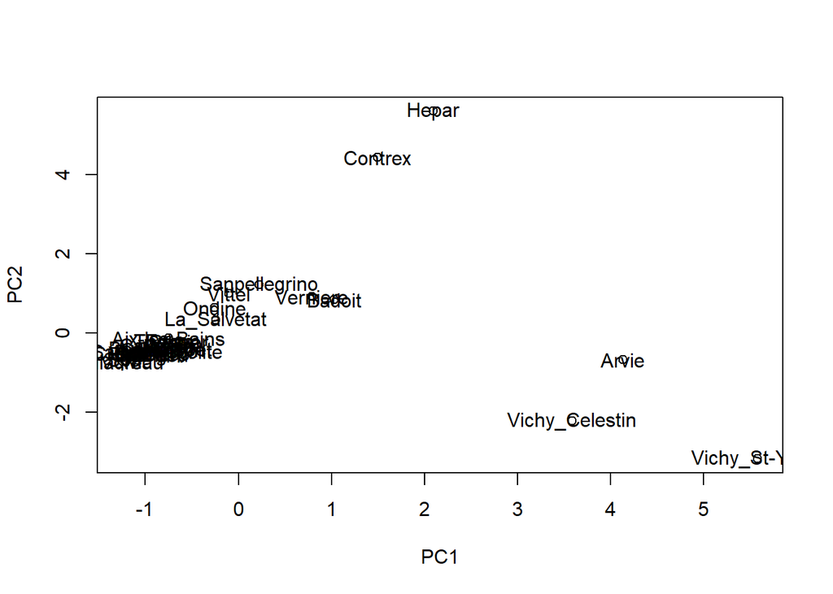

```r
pca <- prcomp(d[,-c(1,2)], center = TRUE, scale. = TRUE)

df <- scale(d[,-c(1,2)], pca$center, pca$scale) %*% pca$rotation
plot(df)
text(df, label=d$Nom)
```

Les eaux qui sortent du lot sont Hepar, Contrex, Arvie, Vichy Celestin et Vichy St-Yorre. On pourrait aussi dire que Sanpellegrino, Vittel, Ondine, Verniere, Badoit et Salveta sortent du lot.

# 7.

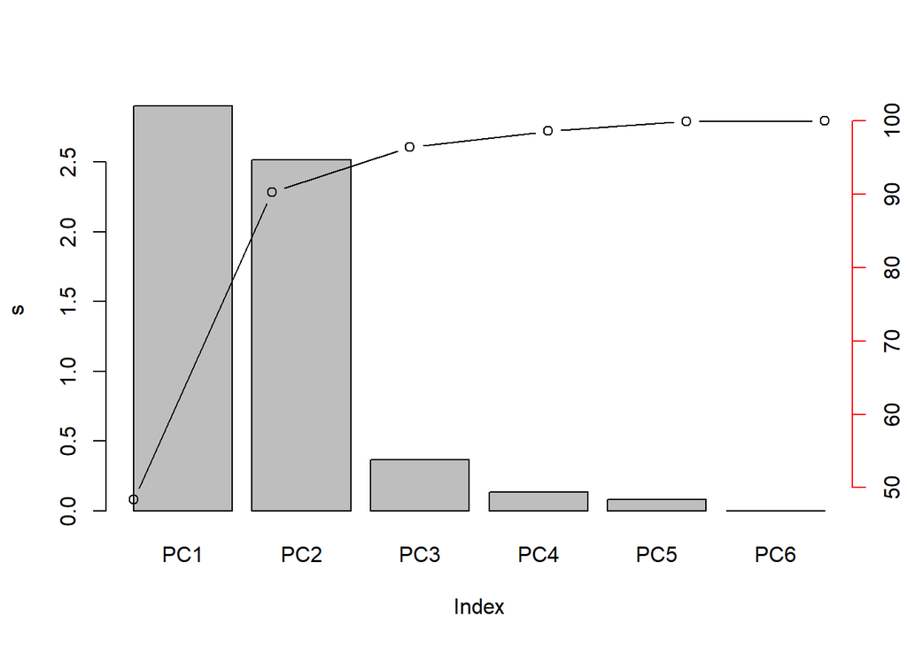

```r
barplot(pr$sdev ^ 2, names.arg = c('PC1', 'PC2', 'PC3', 'PC4', 'PC5', 'PC6'))
par(new = TRUE)
s = cumsum((pr$sdev ^ 2) * 100 / sum(pr$sdev ^ 2))
plot(s, type = 'b', axes = FALSE)
axis(4, col = 'red')
```

On retient deux composantes car elles représentent environ 90% de l’information.

# 8.

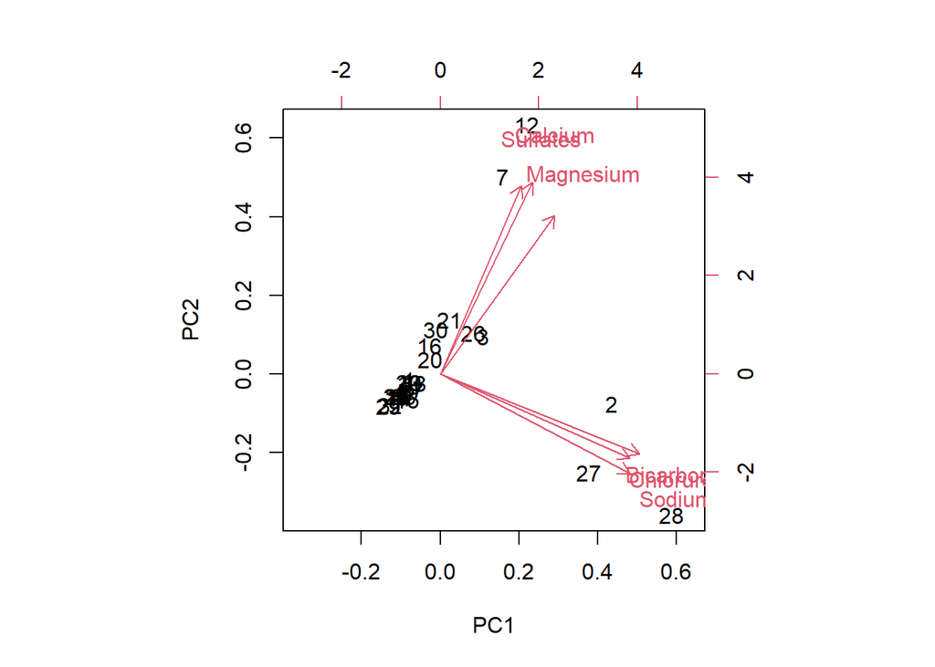

```r
biplot(pr)
```

Le magnésium, les sulfates et le calcium semblent être corrélés entre eux, tout comme le bicarbonatem, le sodium et le chlorures.

# 9.

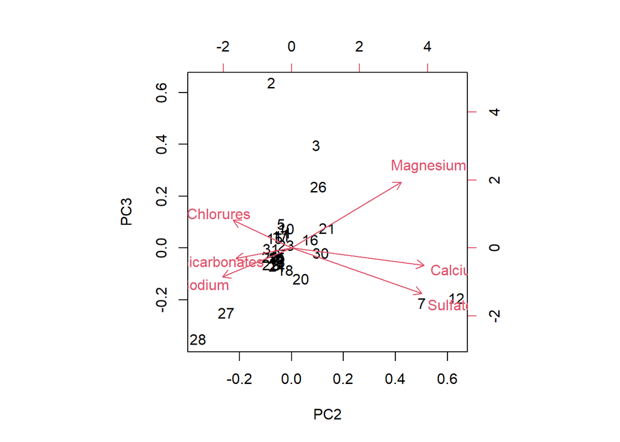

```r
biplot(pr, choices = 2:3)
```

On perd toute corrélation en choisissant les composantes principales 2 et 3.

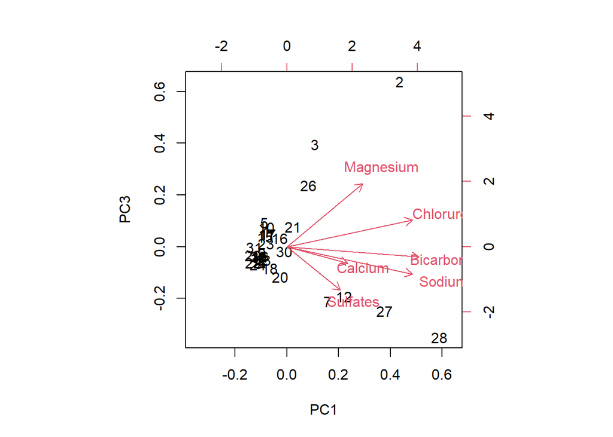

```r
biplot(pr, choices = c(1,3))
```

Même réponse en prenant les composantes principales 1 et 3.

# 10.

```r
square <- pr$rotation ^ 2
rowSums(square)
```

```
## Bicarbonates     Sulfates    Chlorures      Calcium    Magnesium       Sodium
##            1            1            1            1            1            1
```

```r
quality <- rowSums(square[,1:2])
quality
```

```
## Bicarbonates     Sulfates    Chlorures      Calcium    Magnesium       Sodium
##    0.3380922    0.3401092    0.3160365    0.3642490    0.3014868    0.3400264
```

Aucune variable n’a l’air mieux represéntée qu’une autre sur le premier plan factoriel, les valeurs sont environ toutes les mêmes.

##Partitionnement

# 1.

```r
d <- read.table("temperatures.csv", header=TRUE, sep = ";", row.names = 1)
d
```

```
##               January February March April  May June July August September
## Amsterdam         2.9      2.5   5.7   8.2 12.5 14.8 17.1   17.1      14.5
## Anvers            3.1      2.9   6.2   8.9 12.9 15.5 17.9   17.6      14.7
## Athena            9.1      9.7  11.7  15.4 20.1 24.5 27.4   27.2      23.8
## Barcelone         9.1     10.3  11.8  14.1 17.4 21.2 24.2   24.1      21.7
## Berlin           -0.2      0.1   4.4   8.2 13.8 16.0 18.3   18.0      14.4
## Bordeaux          5.6      6.7   9.0  11.9 15.0 18.3 20.4   20.0      17.6
## Brest             6.9      6.8   8.5   9.7 12.6 15.0 17.0   17.0      15.4
## Bruxelles         3.3      3.3   6.7   8.9 12.8 15.6 17.8   17.8      15.0
## Budapest         -1.1      0.8   5.5  11.6 17.0 20.2 22.0   21.3      16.9
## Copenhague       -0.4     -0.4   1.3   5.8 11.1 15.4 17.1   16.6      13.3
## Cracovie         -3.7     -2.0   1.9   7.9 13.2 16.9 18.4   17.6      13.7
## Dublin            4.8      5.0   5.9   7.8 10.4 13.3 15.0   14.6      12.7
## Edimbourg         2.9      3.6   4.7   7.1  9.9 13.0 14.7   14.3      12.1
## Francfort         0.2      1.8   5.4   9.7 14.3 17.5 19.0   18.3      14.8
## Genes             8.7      8.7  11.4  13.8 17.5 21.0 24.5   24.6      21.8
## Geneva            0.1      1.9   5.1   9.4 13.8 17.3 19.4   18.5      15.0
## Helsinki         -5.8     -6.2  -2.7   3.1 10.2 14.0 17.2   14.9       9.7
## Kiev             -5.9     -5.0  -0.3   7.4 14.3 17.8 19.4   18.5      13.7
## Lisbonne         10.5     11.3  12.8  14.5 16.7 19.4 21.5   21.9      20.4
## Londres           3.4      4.2   5.5   8.3 11.9 15.1 16.9   16.5      14.0
## Madrid            5.0      6.6   9.4  12.2 16.0 20.8 24.7   24.3      19.8
## Milan             1.1      3.6   8.0  12.6 17.3 21.3 23.8   22.8      18.9
## Minsk            -6.9     -6.2  -1.9   5.4 12.4 15.9 17.4   16.3      11.6
## Moscou           -9.3     -7.6  -2.0   6.0 13.0 16.6 18.3   16.7      11.2
## Nantes            6.1      6.4   8.9  11.0 14.6 17.7 19.6   19.6      17.0
## Oslo             -4.3     -3.8  -0.6   4.4 10.3 14.9 16.9   15.4      11.1
## Palerme          10.5     11.5  13.3  16.9 20.9 23.8 24.5   22.3      22.3
## Paris             3.7      3.7   7.3   9.7 13.7 16.5 19.0   18.7      16.1
## Prague           -1.3      0.2   3.6   8.8 14.3 17.6 19.3   18.7      14.9
## Reykjavik        -0.3      0.1   0.8   2.9  6.5  9.3 11.1   10.6       7.9
## Rome              7.1      8.2  10.5  13.7 17.8 21.7 24.4   24.1      20.9
## Sarajevo         -1.4      0.8   4.9   9.3 13.8 17.0 18.9   18.7      15.2
## Seville          10.7     11.8  14.1  16.1 19.7 23.4 26.7   26.7      24.3
## Sofia            -1.7      0.2   4.3   9.7 14.3 17.7 20.0   19.5      15.8
## St Petersburg    -8.2     -7.9  -3.7   3.2 10.0 15.4 18.4   16.9      11.5
## Stockholm        -3.5     -3.5  -1.3   3.5  9.2 14.6 17.2   16.0      11.7
## Zurich           -0.7      0.7   4.3   8.5 12.9 16.2 18.0   17.2      14.1
##               October November December Mean Amplitude Latitude Longitude
## Amsterdam        11.4      7.0      4.4  9.9      14.6    52.20      4.50
```

[output cut: 59 more lines]

```
## Minsk           1754.0         690.0       220
## Moscou          1731.0         707.0       156
## Nantes          1954.0         788.0        27
## Oslo            1668.0         763.0        23
## Palerme         2646.0         610.0        14
## Paris           1661.0         649.6        79
## Prague          1667.0         525.0       288
## Reykjavik       1268.0         798.0         2
## Rome            2472.0         804.0        21
## Sarajevo        1769.0         928.0       518
## Seville         2917.4         538.8         7
## Sofia           2177.0         581.0       650
## St Petersburg   1551.0         633.0         3
## Stockholm       1821.0         539.0         1
## Zurich          1531.0        1031.0       408
```

```r
distances <- dist(d[1:12])
```

# 2.

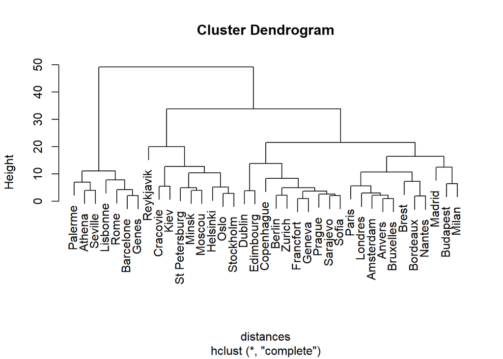

```r
cluster <- hclust(distances)
plot(cluster, main = "Cluster Dendrogram")
```

```r
(dendrogram <- as.dendrogram(cluster))
```

```
## 'dendrogram' with 2 branches and 37 members total, at height 49.10509
```

```r
(cuted <- cut(dendrogram, 21))
```

```
## $upper
## 'dendrogram' with 2 branches and 4 members total, at height 49.10509
##
## $lower
## $lower[[1]]
## 'dendrogram' with 2 branches and 7 members total, at height 11.07384
##
## $lower[[2]]
## 'dendrogram' with 2 branches and 9 members total, at height 20.01375
##
## $lower[[3]]
## 'dendrogram' with 2 branches and 10 members total, at height 13.84124
##
## $lower[[4]]
## 'dendrogram' with 2 branches and 11 members total, at height 16.46086
```

La hauteur représente la différence de températures entre les groupes. On peut couper à la hauteur 21 pour former quatre groupes différents.